# Jakarta Grab Data Analysis

## Get Dataset for Hour Distribution

We first store the date, day of the week and hours of the day where each `trj_id` occurs into the variable `hourdistr`.

```r
#Add time column in WIB
jkt_data_with_time<- jkt_data%>%
  mutate(time = as_datetime(pingtimestamp))%>%
  mutate(time = with_tz(time, tzone = "Asia/Jakarta"))

#Hour distribution
days_of_week<- c("Monday", "Tuesday", "Wednesday", "Thursday", "Friday", "Saturday", "Sunday")
hourdist<- jkt_data_with_time%>%
  mutate(hour = hour(time), day_of_week = weekdays(time), day = day(time))%>%
  mutate(day_of_week = factor(day_of_week, levels = days_of_week))%>%
  distinct(trj_id, hour, day_of_week, day)
```

## Overall distribution of trips by hour

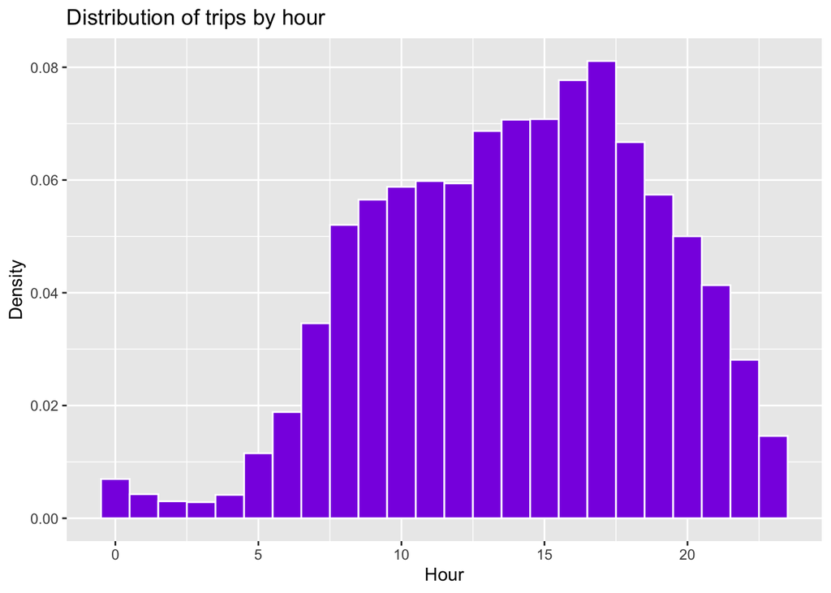

```r
ggplot(hourdist)+
  geom_histogram(aes(hour, y = ..density..), binwidth = 1, color = "white", fill = "blueviolet")+
  labs(title = "Distribution of trips by hour", x = "Hour", y = "Density")
```

By looking at the distribution of trips in every hour, we can see that there is a peak around 4-5pm in the evening. Hence, there are higher demand for grab rides during these hours.

## High Inaccuracy Areas

```r
jkt_data%>%
  filter(accuracy>=200)%>%
  leaflet()%>%
  addTiles()%>%
  addCircleMarkers(lat = ~rawlat, lng= ~rawlng, color = "blueviolet",fillColor = "blueviolet", opacity = 0.05, fillOpacity = 0.1)
```

[interactive chart not shown]

We also analyse the regions where pings had higher inaccuracies. As we can see on the plot, most of the inaccuracies tend to occur along this highway. Other inaccuracies can also be seen around the central area of Jakarta. Particularly along the junctions when the main road meets the highway. Finally we also see a cluster around Bogor and Karawang.

## Distribution of trips by hour, by day of the week

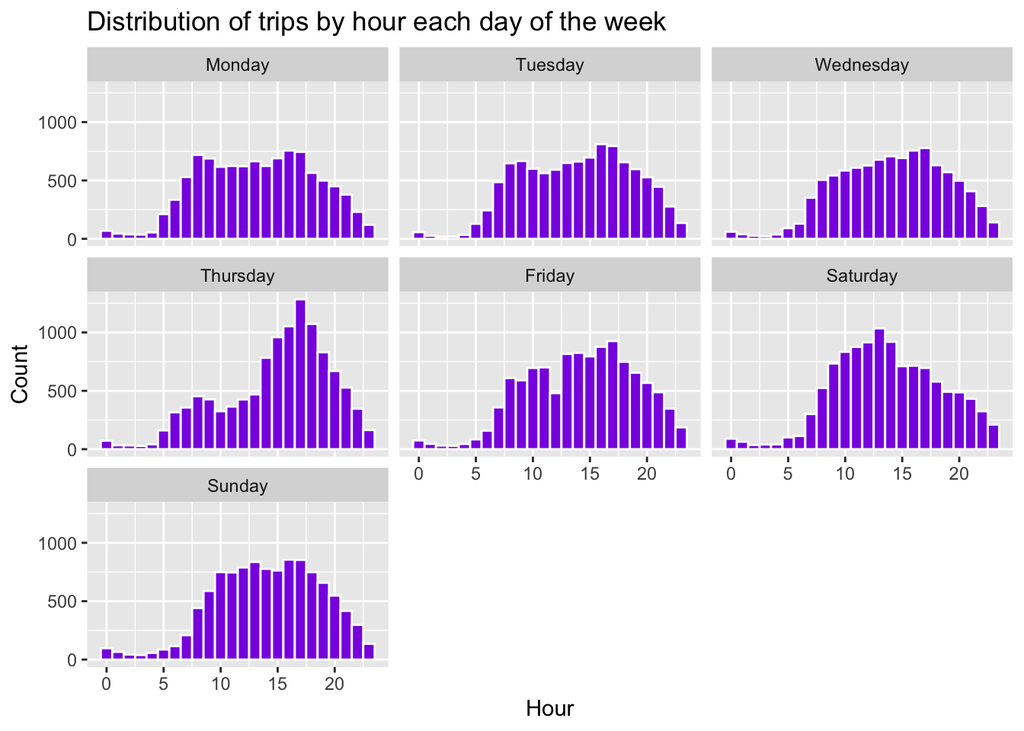

```r
ggplot(hourdist)+
  geom_histogram(aes(hour), binwidth=1, color = "white", fill = "blueviolet")+
  labs(title = "Distribution of trips by hour each day of the week", x = "Hour", y = "Count")+
  facet_wrap(~day_of_week)
```

## Possible impact of Election & Good Friday

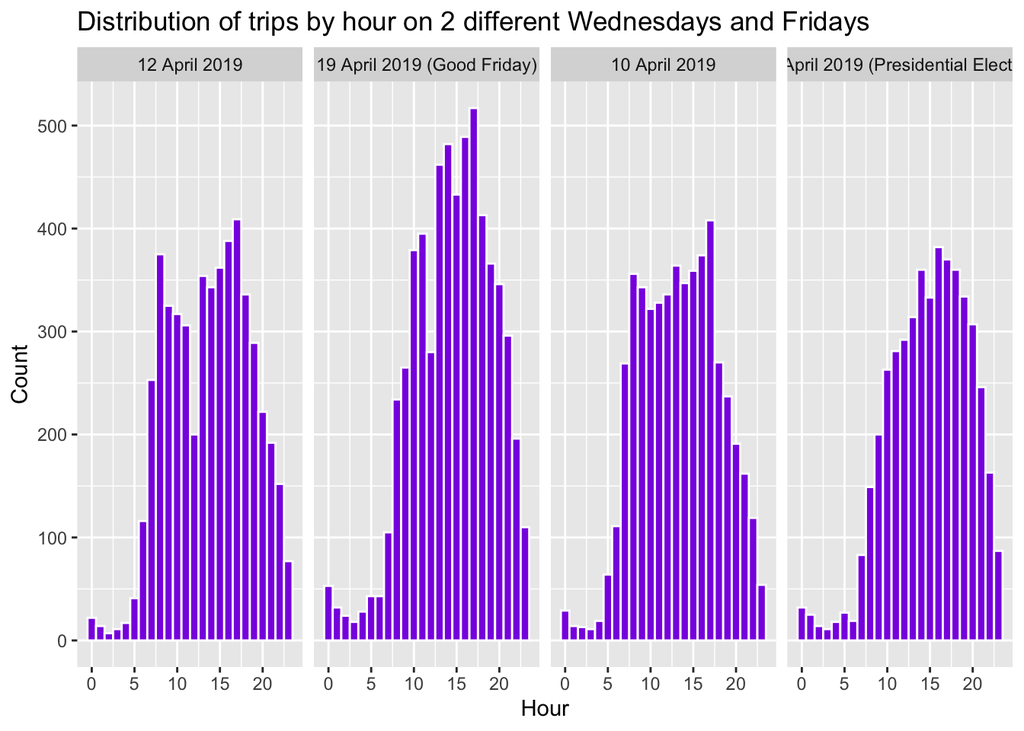

```r
hols<- c(12,19,10,17)
labels_hols<- c("12" = "12 April 2019", "19" = "19 April 2019 (Good Friday)", "10" = "10 April 2019", "17" = "17 April 2019 (Presidential Election)")

hourdist%>%
  filter(day %in% hols)%>%
  mutate(day = factor(day, levels = hols))%>%
  ggplot()+
  geom_histogram(aes(hour), binwidth = 1, color = "white", fill = "blueviolet")+
  labs(title = "Distribution of trips by hour on 2 different Wednesdays and Fridays", y = "Count", x= "Hour")+
  facet_wrap(~day, labeller = as_labeller(labels_hols), nrow = 1)
```

Out of the 2 Fridays in the data, 19 April 2019 is a Good Friday public holiday. We compare the distribution by hour on 19 April with the distribution on 12 April. The plot shows that aggregate demand on Good Friday is higher. The rise/spike in data occurs much later in the day on Good Friday (after 10 am), and peaks around 1-5pm.

## Possible impact of weather

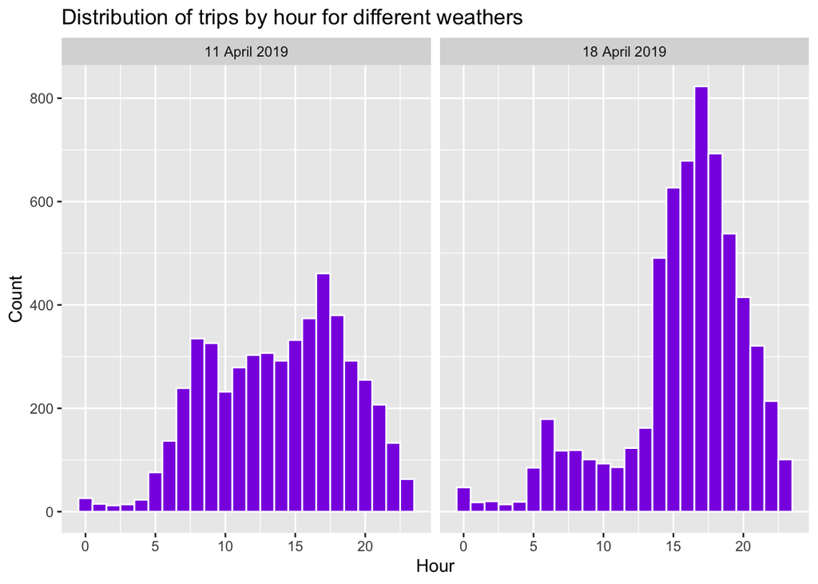

```r
weathers<- c(11,18)
labels_weather<- c("11" = "11 April 2019", "18" = "18 April 2019")

hourdist%>%
  filter(day %in% weathers)%>%
  ggplot()+
  geom_histogram(aes(hour), binwidth = 1, color = "white", fill = "blueviolet")+
  labs(title = "Distribution of trips by hour for different weathers", y = "Count", x= "Hour")+
  facet_wrap(~day, labeller = as_labeller(labels_weather), nrow = 1)
```

Between the 2 Thursdays in our data, 11 April had a regular weather, with some haze before 9am in the morning while 18 April had thunderstorm 2-7pm. Although the demands in both days spike in evening hours, the demand on 18 April, 3-6pm is nearly double than the demand on 11 April evening hours.